# Part I - (Prosper loans dataset presentation)

### **What is the majority of income range? and what is the most common occupation?**

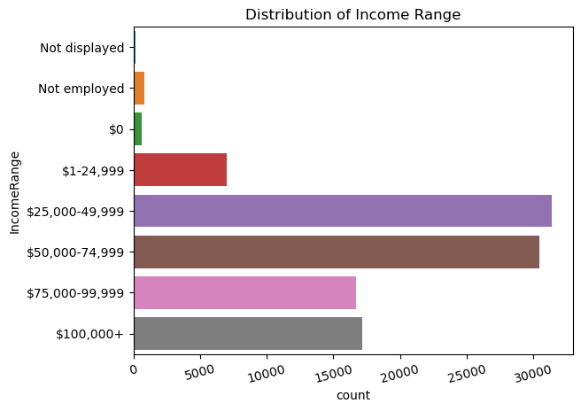

```python
count_plot(df2,'IncomeRange',['Not displayed','Not employed','$0','$1-24,999','$25,000-49,999','$50,000-74,999','$75,000-99,999','$100,000+'],'Distribution of Income Range');
plt.xticks(rotation=15);
```

```python
df2['IncomeRange'].value_counts()
```

```
$25,000-49,999    31360
$50,000-74,999    30423
$100,000+         17148
$75,000-99,999    16688
$1-24,999          6989
Not employed        805
$0                  621
Not displayed       139
Name: IncomeRange, dtype: int64
```

```python
# Convert from categorical to numeric
df2['IncomeRange'].replace(['Not displayed', '$0','Not employed','$1-24,999','$25,000-49,999','$50,000-74,999','$75,000-99,999','$100,000+'],
                        [0, 1,2,3,4,5,6,7], inplace=True)
```

```python
# Change 0 and not employed as the same category
df2['IncomeRange'].replace(2,1,inplace=True)
```

```python
df2['IncomeRange']=df2['IncomeRange'].astype(int)
```

```python
df2['Occupation'].value_counts().head(10)
```

```
Other                       26889
Professional                12936
Computer Programmer          4182
Executive                    4120
Teacher                      3585
Administrative Assistant     3497
Analyst                      3423
Sales - Commission           3159
Accountant/CPA               3095
Clerical                     2832
Name: Occupation, dtype: int64
```

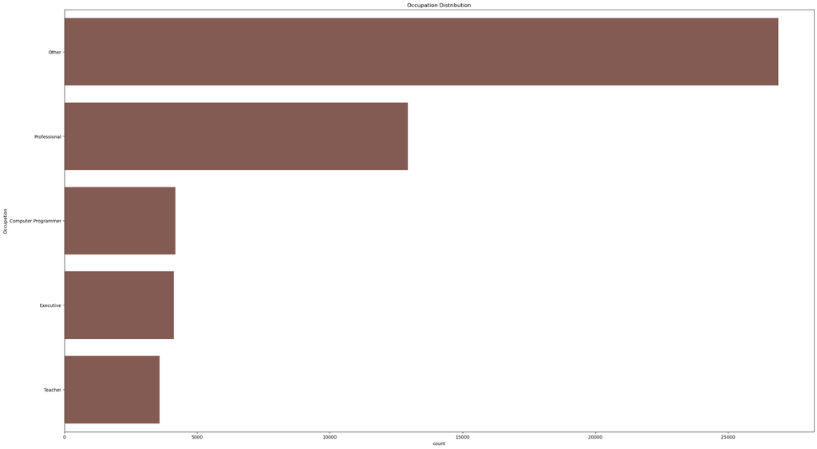

```python
c5 = sns.color_palette()[5]
plt.figure(figsize= [30, 17])
sns.countplot(data=df2, y= 'Occupation',order = df2['Occupation'].value_counts().iloc[:5].index,color=c5);
plt.title("Occupation Distribution")
```

> 1. The majority of borrowers income falls between 25k-74.99k dollar.
> 2. Top 5 occupation in our dataset: Others, professional, Computer programmer, Executive, Teacher

## Bivariate Exploration

> In this section, investigate relationships between pairs of variables in your data. Make sure the variables that you cover here have been introduced in some fashion in the previous section (univariate exploration).

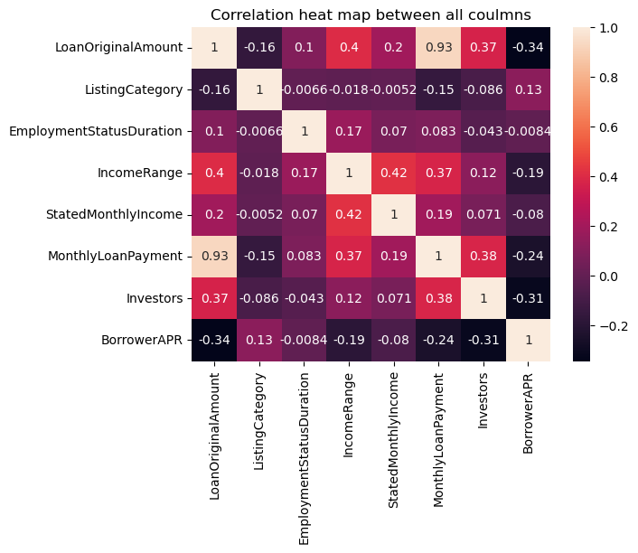

```python
sns.heatmap(df2[['LoanOriginalAmount','ListingCategory','EmploymentStatusDuration','IncomeRange','StatedMonthlyIncome','MonthlyLoanPayment','Investors','BorrowerAPR']].corr(),annot = True);
plt.title('Correlation heat map between all coulmns');
```

### Did you observe any interesting relationships between the other features (not the main feature(s) of interest)?

> There is high correlation between MonthlyLoanPayment and LoanOriginalAmount

## Multivariate Exploration

> Create plots of three or more variables to investigate your data even further. Make sure that your investigations are justified, and follow from your work in the previous sections.

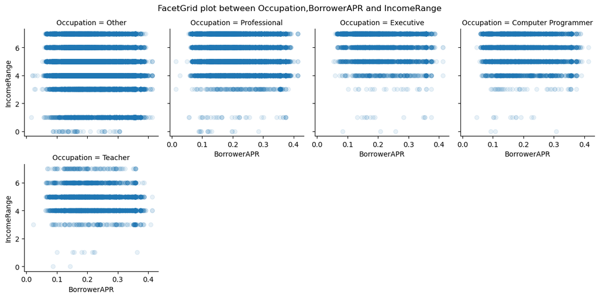

```python
grid = sns.FacetGrid(data = df2[df2['Occupation'].isin(df2['Occupation'].value_counts().iloc[:5].index)], col = 'Occupation', col_wrap = 4);
grid.map(plt.scatter, 'BorrowerAPR', 'IncomeRange', alpha = 0.1);
grid.fig.subplots_adjust(top=0.9);
grid.fig.suptitle('FacetGrid plot between Occupation,BorrowerAPR and IncomeRange');
grid.set_xlabels('BorrowerAPR');
grid.set_ylabels('IncomeRange');

plt.show();
```

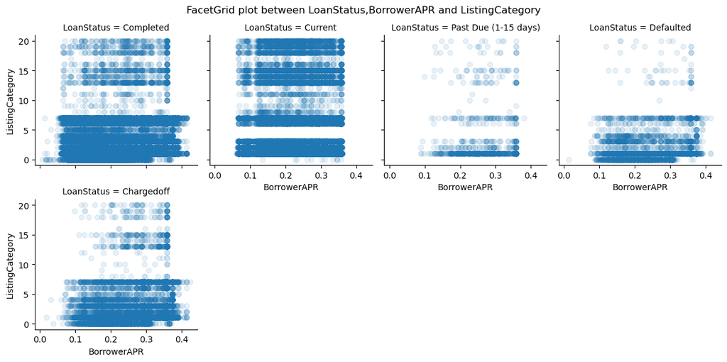

```python
grid = sns.FacetGrid(data = df2[df2['LoanStatus'].isin(df2['LoanStatus'].value_counts().iloc[:5].index)], col = 'LoanStatus', col_wrap = 4);
grid.map(plt.scatter, 'BorrowerAPR', 'ListingCategory', alpha = 0.1);
grid.fig.subplots_adjust(top=0.9);
grid.fig.suptitle('FacetGrid plot between LoanStatus,BorrowerAPR and ListingCategory');
grid.set_xlabels('BorrowerAPR');
grid.set_ylabels('ListingCategory');

plt.show();
```

## checking the features that has effect on loanstatus

```python
# defining the dependent and independent variables
import statsmodels.api as sm
df3=df2[df2['LoanStatus'].isin(['Current','Completed','Chargedoff','Defaulted'])]
Xtrain = df3[['LoanOriginalAmount','ListingCategory','EmploymentStatusDuration','IncomeRange','StatedMonthlyIncome','MonthlyLoanPayment','Investors','BorrowerAPR']]
ytrain = df3[['LoanStatus']].replace(['Current','Completed','Chargedoff','Defaulted'],[0,1,2,3])

# building the model and fitting the data
log_reg = sm.MNLogit(ytrain, Xtrain).fit()
```

```
Optimization terminated successfully.
         Current function value: 0.842346
         Iterations 12
```

```python
print(log_reg.summary());
```

```
                          MNLogit Regression Results
==============================================================================
Dep. Variable:             LoanStatus   No. Observations:               101927
Model:                        MNLogit   Df Residuals:                   101903
Method:                           MLE   Df Model:                           21
Date:                Wed, 08 Feb 2023   Pseudo R-squ.:                  0.1956
Time:                        01:06:28   Log-Likelihood:                -85858.
converged:                       True   LL-Null:                   -1.0674e+05
Covariance Type:            nonrobust   LLR p-value:                     0.000
============================================================================================
            LoanStatus=1       coef    std err          z      P>|z|      [0.025      0.975]
--------------------------------------------------------------------------------------------
LoanOriginalAmount          -0.0005   6.09e-06    -86.344      0.000      -0.001      -0.001
ListingCategory             -0.0392      0.002    -19.633      0.000      -0.043      -0.035
EmploymentStatusDuration    -0.0020   9.31e-05    -21.585      0.000      -0.002      -0.002
IncomeRange                  0.1146      0.007     16.761      0.000       0.101       0.128
StatedMonthlyIncome      -1.324e-05   2.75e-06     -4.815      0.000   -1.86e-05   -7.85e-06
MonthlyLoanPayment           0.0078      0.000     45.341      0.000       0.007       0.008
Investors                    0.0149      0.000    113.647      0.000       0.015       0.015
BorrowerAPR                  0.2357      0.091      2.592      0.010       0.057       0.414
--------------------------------------------------------------------------------------------
            LoanStatus=2       coef    std err          z      P>|z|      [0.025      0.975]
--------------------------------------------------------------------------------------------
LoanOriginalAmount          -0.0005   7.76e-06    -61.430      0.000      -0.000      -0.000
ListingCategory             -0.0714      0.003    -22.443      0.000      -0.078      -0.065
EmploymentStatusDuration    -0.0022      0.000    -15.829      0.000      -0.002      -0.002
IncomeRange                 -0.3546      0.008    -45.692      0.000      -0.370      -0.339
StatedMonthlyIncome       1.659e-06   1.16e-06      1.435      0.151   -6.06e-07    3.92e-06
MonthlyLoanPayment           0.0084      0.000     40.325      0.000       0.008       0.009
Investors                    0.0132      0.000     76.617      0.000       0.013       0.014
BorrowerAPR                  3.8983      0.114     34.124      0.000       3.674       4.122
--------------------------------------------------------------------------------------------
            LoanStatus=3       coef    std err          z      P>|z|      [0.025      0.975]
--------------------------------------------------------------------------------------------
LoanOriginalAmount          -0.0005   1.17e-05    -42.019      0.000      -0.001      -0.000
ListingCategory             -0.1651      0.008    -21.977      0.000      -0.180      -0.150
EmploymentStatusDuration    -0.0023      0.000    -10.024      0.000      -0.003      -0.002
IncomeRange                 -0.3971      0.012    -33.940      0.000      -0.420      -0.374
StatedMonthlyIncome       2.092e-06   1.48e-06      1.410      0.159   -8.16e-07       5e-06
MonthlyLoanPayment           0.0081      0.000     26.335      0.000       0.008       0.009
Investors                    0.0145      0.000     56.921      0.000       0.014       0.015
BorrowerAPR                  0.8466      0.181      4.686      0.000       0.492       1.201
============================================================================================
```

- From P values using multinomial logit we can say that all above feature affect on LoanStatus except StatedMonthlyIncome affect only i can loanStatus ( Completed )